# Project 2: Heatwave analysis for Italy

*ABDILLAHI AHMED Mariam, EL HADAD Chaïma, HILLAH Kelly*

**Objective**: We the examine consequences of the summer 2022 heatwave for Italy.

This project is loosely based on Ballester et al. (2023) who conduct a quantitative analysis of the mortality-temperature relationship using the NUTS3 spatial resolution (both for mortality figures and ERA5 temperature scans). Below, we use mortality data for the whole of Italy, so results will differ from those of Ballester et al. (2023).

- Ballester , J. et al. (2023). Heat-related mortality in Europe during the summer of 2022. *Nature Medicine*.

## 1. Preliminaries: The temperature data for Italy

Task 1.1: Generate the ERA5 data extract for Italy using the API of daily-hourly data starting in 2015. As a consequence, the reference period for our analysis will be 2015-2020, when we assess the situation in the summer of 2022. Recall that the coordinates are (anti-clockwise): [N,W,S,E]. The bounding box for Italy is [46,9,37,18.5,]

```python
!pip install cartopy
import cartopy
```

```python
# Libraries
import numpy as np
import pandas as pd
import xarray as xr
import matplotlib.path as mpath
import matplotlib.pyplot as plt
import cartopy.crs as ccrs
from cartopy.mpl.gridliner import LONGITUDE_FORMATTER, LATITUDE_FORMATTER
import cartopy.feature as cfeature
import urllib3
urllib3.disable_warnings()
```

```python
!pip install "cdsapi>=0.7.7"
```

```python
import cdsapi

DATADIR = './'

## Get the Data
URL = "https://cds.climate.copernicus.eu/api"
KEY = "d79bfea5-f171-4f4f-b822-0c2bae301fb1"

c = cdsapi.Client(url=URL, key=KEY)

c.retrieve(
    'reanalysis-era5-single-levels',
    {
        'product_type': 'reanalysis',
        'data_format': 'netcdf_legacy',
        'variable': '2m_temperature',
        'year': [
            '2015', '2016', '2017',
            '2018', '2019', '2020',
            '2021','2022',  '2023'
        ],
        'month': [
            '01', '02', '03',
            '04', '05', '06',
            '07', '08', '09',
            '10', '11', '12',
        ],
        'day': [
            '01', '02', '03',
            '04', '05', '06',
            '07', '08', '09',
            '10', '11', '12',
            '13', '14', '15',
            '16', '17', '18',
            '19', '20', '21',
            '22', '23', '24',
            '25', '26', '27',
            '28', '29', '30',
        ],
        'time': [
            '00:00', '01:00', '02:00',
            '03:00', '04:00', '05:00',
            '06:00', '07:00', '08:00',
            '09:00', '10:00', '11:00',
            '12:00', '13:00', '14:00',
            '15:00', '16:00', '17:00',
            '18:00', '19:00', '20:00',
            '21:00', '22:00', '23:00',
        ],
        'area': [46, 9, 37, 18.5],
    },
    f'{DATADIR}Italy_hourly_2015_2022.nc')
```

```
2026-04-10 17:30:27,585 INFO [2025-12-11T00:00:00] Please note that a dedicated catalogue entry for this dataset, post-processed and stored in Analysis Ready Cloud Optimized (ARCO) format (Zarr), is available for optimised time-series retrievals (i.e. for retrieving data from selected variables for …
2026-04-10 17:30:27,586 INFO Request ID is 4ebd1ffc-ab1e-4094-a3c1-02a6b02ccd2c
2026-04-10 17:30:27,663 INFO status has been updated to accepted
2026-04-10 17:30:41,254 INFO status has been updated to successful
```

```
'./Italy_hourly_2015_2022.nc'
```

As per usual, we consider the temperature at 2 meters and convert into Celsius.

```python
filename = DATADIR + "Italy_hourly_2015_2022.nc"
ds = xr.open_dataset(filename)

da = ds['t2m']       # surface temp. at 2 meters
t2m_C = da - 273.15  # convert from Kelvin to Celsius

del ds, da
```

**Task 1.2**: Then aggregate hourly local data for the week, and then aggregate the local measures. Display the map. Finally, write the data to dis as a csv file.

```python
print(t2m_C)
```

[output not shown]

```python
# Aggregate hourly -> daily means
year_month_day_mean = t2m_C.groupby(['time.year', 'time.month', 'time.day']).mean()

# Aggregate spatially with cosine latitude weighting
weights = np.cos(np.deg2rad(year_month_day_mean.latitude))
weights = weights.fillna(0)
weights.name = "weights"
year_month_day_mean_weighted = year_month_day_mean.weighted(weights)
Italy_t2m = year_month_day_mean_weighted.mean(["longitude", "latitude"])
```

```python
import os
os.makedirs("pics", exist_ok=True)
```

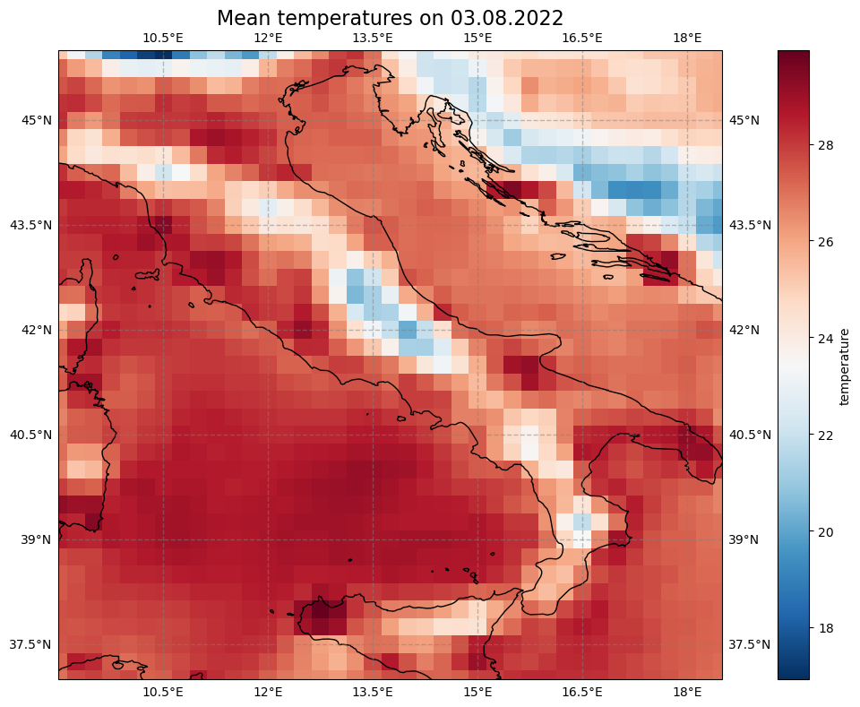

```python
# Plot the Heat Map
fig, ax = plt.subplots(1, 1, figsize=(16, 8),
                       subplot_kw={'projection': ccrs.PlateCarree()})

im = plt.pcolormesh(year_month_day_mean.longitude,
                    year_month_day_mean.latitude,
                    year_month_day_mean.sel(year=2022, month=8, day=3),
                    cmap='RdBu_r',
                    vmin=year_month_day_mean.sel(year=2022, month=8, day=3).min(),
                    vmax=year_month_day_mean.sel(year=2022, month=8, day=3).max())

ax.set_title('Mean temperatures on 03.08.2022', fontsize=16)
ax.gridlines(draw_labels=True, linewidth=1, color='gray', alpha=0.5, linestyle='--')
ax.coastlines(color='black')
ax.set_extent([9, 18.5, 37, 46], crs=ccrs.PlateCarree())

cbar = plt.colorbar(im, fraction=0.05, pad=0.04)
cbar.set_label('temperature')

fig.tight_layout()
fig.savefig("pics/map_Italy_August2022.png", bbox_inches='tight')
plt.show()
```

```python
# Convert to DataFrame
df = Italy_t2m.to_dataframe()
df = df.reset_index()

# Drop Feb 29
df = df.drop(df[(df.month == 2) & (df.day > 28)].index)

# Create date and week columns
df['date'] = pd.to_datetime(df[['year', 'month', 'day']])
df['week'] = df['date'].dt.isocalendar().week

# Aggregate to weekly and save CSV
temp = df.groupby(['year', 'week'])['t2m'].mean().reset_index()

print(temp.head(10))

temp.to_csv(DATADIR + "italy_temp_weekly.csv", index=False)
```

```
   year  week        t2m
0  2015     1   8.485495
1  2015     2   9.639419
2  2015     3  10.757957
3  2015     4   9.609714
4  2015     5   7.750729
5  2015     6   7.667161
6  2015     7   8.123645
7  2015     8   9.154508
8  2015     9   9.831842
9  2015    10   9.972127
```

The hourly data was aggregated to daily means using `groupby` on year, month, and day. A cosine latitude weighting was applied before taking the spatial mean, since grid cells closer to the equator cover more surface area than those near the poles. This gives a single daily mean temperature representative of all of Italy. The map above shows the spatial temperature distribution on 03.08.2022 — the peak of the heatwave — with most of the peninsula showing temperatures between 22–28°C. The daily series was then aggregated to weekly means and saved as a CSV file with columns `year`, `week`, and `t2m`.

**Task 1.3**: Switch to **R**, load your csv-file of the temperature data, and visualise this temperature data. Consider the summer of 2022 starting in June and finishing end of August. I get the following graph:

```python
!pip install rpy2
```

```python
import subprocess
result = subprocess.run(['where', 'R'], capture_output=True, text=True)
print(result.stdout)
```

```python
import os
import sys

# 1. Set the exact R_HOME
os.environ['R_HOME'] = r'C:\Program Files\R\R-4.5.3'

# 2. Put the correct R bin directory at the front of PATH
r_bin = r'C:\Program Files\R\R-4.5.3\bin\x64'
os.environ['PATH'] = r_bin + ';' + os.environ.get('PATH', '')

# 3. Critical for Windows: add the directory to the DLL search path
if sys.platform == 'win32':
    os.add_dll_directory(r_bin)

# 4. (Optional) Clear R_USER to avoid loading user‑library conflicts
os.environ.pop('R_USER', None)
```

```python
%load_ext rpy2.ipython
```

```python
%%R
library(stats)
print("stats loaded")
```

```
[1] "stats loaded"
```

```python
%%R
library(tidyverse)
print("tidyverse loaded successfully")
```

```
[1] "tidyverse loaded successfully"
```

```python
%%R
library(tidyverse)

# Load the CSV
temp <- read_csv("italy_temp_weekly.csv")
print(temp)

# Create proper date column
temp <- temp %>%
  mutate(date = as.Date(paste(year, week, 1), format="%Y %U %u"))
```

```
# A tibble: 472 x 3
    year  week   t2m
   <dbl> <dbl> <dbl>
 1  2015     1  8.49
 2  2015     2  9.64
 3  2015     3 10.8
 4  2015     4  9.61
 5  2015     5  7.75
 6  2015     6  7.67
 7  2015     7  8.12
 8  2015     8  9.15
 9  2015     9  9.83
10  2015    10  9.97
# i 462 more rows
# i Use `print(n = ...)` to see more rows
```

```
In addition: Warning message:
There were 4 warnings in `mutate()`.
The first warning was:
i In argument: `date = as.Date(paste(year, week, 1), format = "%Y %U %u")`.
Caused by warning in `strptime()`:
! (0-based) yday 368 in year 2015 is invalid
i Run `dplyr::last_dplyr_warnings()` to see the 3 remaining warnings.
```

```
R callback write-console: In addition:
R callback write-console: Warning message:

R callback write-console: Removed 4 rows containing missing values or values outside the scale range (`geom_line()`).
```

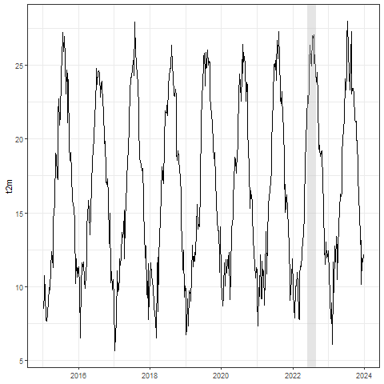

```python
%%R
# Plot with summer 2022 highlighted
ggplot(temp, aes(x = date, y = t2m)) +
  geom_line() +
  annotate("rect",
           xmin = as.Date("2022-06-01"),
           xmax = as.Date("2022-08-31"),
           ymin = -Inf, ymax = Inf,
           fill = "gray", alpha = 0.4) +
  labs(x = NULL, y = "t2m") +
  theme_bw()
```

## 2. The Mortality Data

**Task 2.1**: Use of the [World Mortality Dataset](https://github.com/akarlinsky/world_mortality) compiled by Ariel Karlinsky and Dmitry Kobak that records all-cause mortality at a weekly level. Filter Italy, which has `iso3c` code `"ITA"`.

First, we do it in R langage.

```python
%%R
library(tidyverse)

# Load the World Mortality Dataset
world_mort <- read_csv("https://raw.githubusercontent.com/akarlinsky/world_mortality/main/world_mortality.csv")

# Define get_date function like the prof
get_date <- function(week, year) {
  as.Date(paste(year, week, 1, sep="-"), format="%Y-%W-%u")
}

country <- "Italy"  ## iso3c == "ITA"

world_mort %>%
  filter(iso3c == "ITA") %>%
  select(-c(iso3c, country_name, time_unit)) %>%
  rename(mortality = deaths, week = time) %>%
  mutate(start_date = get_date(week=week, year=year)) ->
  mortality

rm(world_mort)

print(mortality)
```

```
# A tibble: 522 x 4
    year  week mortality start_date
   <dbl> <dbl>     <dbl> <date>
 1  2015     1     15178 2015-01-05
 2  2015     2     15811 2015-01-12
 3  2015     3     15480 2015-01-19
 4  2015     4     14922 2015-01-26
 5  2015     5     15228 2015-02-02
 6  2015     6     15640 2015-02-09
 7  2015     7     15510 2015-02-16
 8  2015     8     15149 2015-02-23
 9  2015     9     14544 2015-03-02
10  2015    10     14211 2015-03-09
# i 512 more rows
# i Use `print(n = ...)` to see more rows
```

```
In addition: Warning message:
There were 2 warnings in `mutate()`.
The first warning was:
i In argument: `start_date = get_date(week = week, year = year)`.
Caused by warning in `strptime()`:
! (0-based) yday 368 in year 2015 is invalid
i Run `dplyr::last_dplyr_warnings()` to see the 1 remaining warning.
```

```python
# Load mortality data
mortality = pd.read_csv("https://raw.githubusercontent.com/akarlinsky/world_mortality/main/world_mortality.csv")

# Filter for Italy
mortality = mortality[mortality['iso3c'] == 'ITA'].copy()
mortality = mortality.drop(columns=['iso3c', 'country_name', 'time_unit'])
mortality = mortality.rename(columns={'deaths': 'mortality', 'time': 'week'})
mortality['start_date'] = pd.to_datetime(
    mortality['year'].astype(str) + '-' +
    mortality['week'].astype(str) + '-1',
    format='%Y-%W-%w')

print(mortality)
```

```
       year  week  mortality start_date
15950  2015     1    15178.0 2015-01-05
15951  2015     2    15811.0 2015-01-12
15952  2015     3    15480.0 2015-01-19
15953  2015     4    14922.0 2015-01-26
15954  2015     5    15228.0 2015-02-02
...     ...   ...        ...        ...
16467  2024    48    13173.0 2024-11-25
16468  2024    49    12995.0 2024-12-02
16469  2024    50    13214.0 2024-12-09
16470  2024    51    13313.0 2024-12-16
16471  2024    52    13969.0 2024-12-23

[522 rows x 4 columns]
```

## 3. A simple time-series model of excess mortality

**Task 3**: Next, estimate a simple time-series model of excess mortality for the period **before** 2020-03-01, which only considers a linear year effect and week fixed effects. Then use the model to predict mortality for the summer of 2022, and compute the measure of excess mortality (i.e. observed - predicted weekly mortality from all causes).

To estimate excess mortality during the summer of 2022, we first build a **baseline model** using data before 2020-03-01, which coincide with the pre-COVID period. The model is a simple linear regression of the form:

$$mortality = \beta_0 + \beta_1 \cdot year + \sum_{w=1}^{52} \gamma_w \cdot \mathbb{1}[week = w] + \varepsilon$$

It includes two components:

- **Linear year effect** ($\beta_1 \cdot year$): captures the long-run downward trend in mortality over time
- **Week fixed effects** ($\gamma_w$): captures seasonal patterns — mortality is systematically higher in winter and lower in summer

We use this model to predict what mortality *would have been* in the summer of 2022 under normal conditions.

Excess mortality is defined as: $$\text{excess deaths} = \text{observed mortality} - \text{predicted mortality}$$

We implement this model twice:

- First in **R** using `lm()` with `as.factor(week)` for the week fixed effects.

```
Ignoring unknown labels:
* colour : ""
Total number of excess deaths in Italy in summer of 2022: 27525.08
```

```
In addition: Warning message:
No shared levels found between `names(values)` of the manual scale and the data's colour values.
```

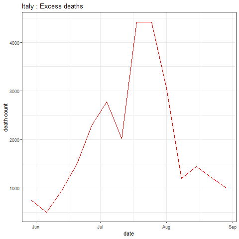

```python
%%R
# Estimate time-series model before 2020-03-01
mortality_train <- mortality %>%
  filter(start_date < as.Date("2020-03-01"))

# Simple model: linear year effect + week fixed effects
model <- lm(mortality ~ year + as.factor(week), data = mortality_train)

# Predict for summer 2022 (June to end of August)
summer_2022 <- mortality %>%
  filter(year == 2022, week >= 22, week <= 35)

# Compute excess mortality (observed - predicted)
summer_2022 <- summer_2022 %>%
  mutate(predicted = predict(model, newdata = summer_2022),
         excess = mortality - predicted)

# Plot excess deaths
plot <- ggplot(summer_2022, aes(x = start_date, y = excess)) +
  geom_line(color = "red") +
  labs(title = paste("Italy : Excess deaths"),
       x = "date",
       y = "death count",
       color = "") +
  scale_color_manual(values = c("excess deaths" = "red")) +
  theme_bw()

print(plot)
# Total excess deaths
cat("Total number of excess deaths in", country, "in summer of 2022:",
    sum(summer_2022$excess))
```

- Then in **Python** using `statsmodels` with `C(week)` which produces an identical model specification.

Both implementations produce the same result:

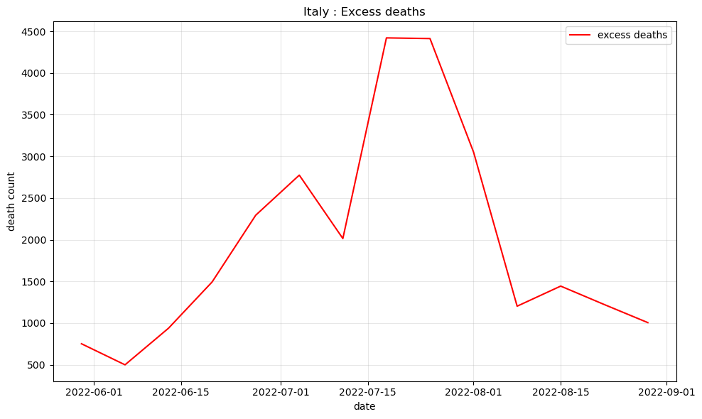

```
Total number of excess deaths in Italy in summer of 2022: 27525.08
```

```python
from statsmodels.formula.api import ols
# Train model BEFORE 2020-03-01
mortality_train = mortality[mortality['start_date'] < '2020-03-01'].copy()
mortality_train['week'] = mortality_train['week'].astype(str)

# Use statsmodels formula API - identical to R's lm()
model = ols('mortality ~ year + C(week)', data=mortality_train).fit()

# Summer 2022 (week 22-35)
summer_2022 = mortality[(mortality['year'] == 2022) &
                         (mortality['week'] >= 22) &
                         (mortality['week'] <= 35)].copy()
summer_2022['week'] = summer_2022['week'].astype(str)

# Predict and compute excess
summer_2022['predicted'] = model.predict(summer_2022)
summer_2022['excess'] = summer_2022['mortality'] - summer_2022['predicted']

# Plot
fig, ax = plt.subplots(figsize=(10, 6))
ax.plot(summer_2022['start_date'], summer_2022['excess'],
        color='red', label='excess deaths')
ax.set_title('Italy : Excess deaths')
ax.set_xlabel('date')
ax.set_ylabel('death count')
ax.legend()
ax.grid(True, alpha=0.3)
plt.tight_layout()
plt.show()

# Total excess deaths
print(f"Total number of excess deaths in Italy in summer of 2022: {summer_2022['excess'].sum():.2f}")
```

## 4. The mortality and temperature relationship

**Task 4**: Finally consider the (potential all-cause) mortality and temperature relationship using a bin scatter plot.

We want to visualize the relationship between temperature and mortality, here are the steps:

1. Bin the weekly temperature values into 10 equal-width groups
2. Compute the mean temperature and mean mortality within each bin
3. Compute the standard error of mortality within each bin to measure uncertainty
4. Plot the bin scatter plot with each bin as a point with a line segment whose direction follows the local slope of the curve and whose lenghts reflects the standard error.

Same as **Task 3**, we implemented the code in **R** first then in **Python**.

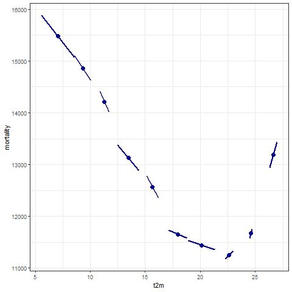

```python
%%R
binned <- combined %>%
  mutate(bin = cut(t2m, breaks = 10)) %>%
  group_by(bin) %>%
  summarise(
    t2m_mean = mean(t2m),
    mortality_mean = mean(mortality),
    se = sd(mortality) / sqrt(n())
  ) %>%
  drop_na()

n <- nrow(binned)

dx <- c(diff(binned$t2m_mean), diff(binned$t2m_mean)[n-1])
dy <- c(diff(binned$mortality_mean), diff(binned$mortality_mean)[n-1])
len <- sqrt(dx^2 + dy^2)

tx_unit <- dx / len
ty_unit <- dy / len

binned$tx <- binned$se * tx_unit
binned$ty <- binned$se * ty_unit

ggplot(binned, aes(x = t2m_mean, y = mortality_mean)) +
  geom_segment(aes(x = t2m_mean - tx, xend = t2m_mean + tx,
                   y = mortality_mean - ty, yend = mortality_mean + ty),
               color = "darkblue", linewidth = 1) +
  geom_point(color = "darkblue", size = 3) +
  labs(x = "t2m", y = "mortality") +
  theme_bw()
```

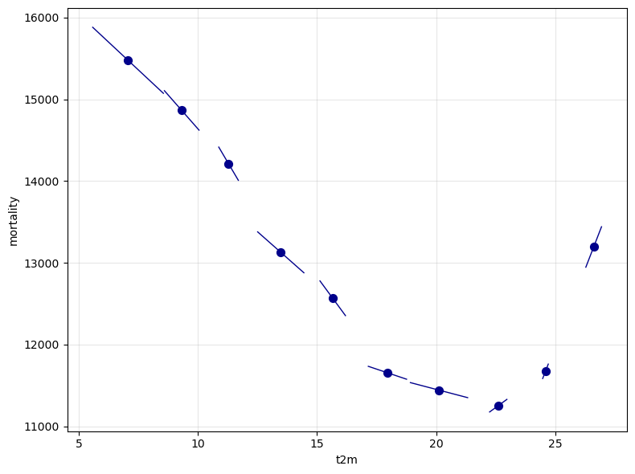

```python
# Merge
combined = mortality.merge(temp, on=['year', 'week'])
combined = combined[combined['week'] <= 52]

# Bin by temperature
combined['bin'] = pd.cut(combined['t2m'], bins=10)
binned = combined.groupby('bin').agg(
    t2m_mean=('t2m', 'mean'),
    mortality_mean=('mortality', 'mean'),
    se=('mortality', lambda x: x.std() / np.sqrt(len(x)))
).dropna().reset_index()

# Compute tangent direction
n = len(binned)
dx = np.append(np.diff(binned['t2m_mean']), np.diff(binned['t2m_mean'])[n-2])
dy = np.append(np.diff(binned['mortality_mean']), np.diff(binned['mortality_mean'])[n-2])
length = np.sqrt(dx**2 + dy**2)

tx_unit = dx / length
ty_unit = dy / length

binned['tx'] = binned['se'] * tx_unit
binned['ty'] = binned['se'] * ty_unit

# Plot
fig, ax = plt.subplots(figsize=(8, 6))
for _, row in binned.iterrows():
    ax.plot([row['t2m_mean'] - row['tx'], row['t2m_mean'] + row['tx']],
            [row['mortality_mean'] - row['ty'], row['mortality_mean'] + row['ty']],
            color='darkblue', linewidth=1)
ax.scatter(binned['t2m_mean'], binned['mortality_mean'],
           color='darkblue', s=50, zorder=5)
ax.set_xlabel('t2m')
ax.set_ylabel('mortality')
ax.grid(True, alpha=0.3)
plt.tight_layout()
plt.show()
```

Both implementation reveal the same clear U-shaped relationship between temperature and mortality:

- At cold temperatures (5°C - 10°C), mortality is high (15,400 deaths/week)
- Mortality decreases as temperatures rise toward a minimum around 20-23°C (approximately 11,000 deaths/week)
- At high temperatures (25°C and more), mortality rises again (13,300 deaths/week).

This U-shaped pattern is consistent with the findings of Ballester et al. (2023).